# Stroke

# 1 Description of DataSchema variable

The description of harmonised variable is the following:

- Short name: `stroke`
- Variable label: `Stroke`
- Variable description: `Diagnosis of stroke or cerebral vascular disease since the last wave`
- Domain: `Diseases`
- Value type: `categorical`
- Category coding:

| **Code** | **Category Label** |
| --- | --- |
| 0 | NOT A stroke (cerebral vascular disease) |
| 1 | A stroke (cerebral vascular disease) |

- Category missings:

| **Code** | **Category Label** |
| --- | --- |
| 991 | CAPI/interviewer error |
| 992 | Impute |
| 993 | Disable to measure |
| 994 | Not attempt/not done |
| 995 | Does not answer |
| 996 | Not applicable |
| 997 | Refuse |
| 998 | Do not know |
| 999 | Missing |

- Short name: `stroke_age`
- Variable label: `Age of each episode of stroke`
- Variable description: `Age of each episode of stroke`
- Domain: `Diseases`
- Value type: `Continuous`
- Category missings:

| **Code** | **Category Label** |
| --- | --- |
| 991 | CAPI/interviewer error |
| 992 | Impute |
| 993 | Disable to measure |
| 994 | Not attempt/not done |
| 995 | Does not answer |
| 996 | Not applicable |
| 997 | Refuse |
| 998 | Do not know |
| 999 | Missing |

# 2 Data process

## 2.1 England

### 2.1.1 Wave 1

#### 2.1.1.1 Study-specific variable description

| **Name** | `hedim01` | `hedim02` | `hedim03` | `hedim04` | `hedim05` | `hedim06` | `hedim07` | `heage` |
| --- | --- | --- | --- | --- | --- | --- | --- | --- |
| **Label** | `MERGED - Has a doctor ever told you that you [have/have had] any of the conditions in this card? {heart conditions}` | `MERGED - Has a doctor ever told you that you [have/have had] any of the conditions in this card? {heart conditions}` | `MERGED - Has a doctor ever told you that you [have/have had] any of the conditions in this card? {heart conditions}` | `MERGED - Has a doctor ever told you that you [have/have had] any of the conditions in this card? {heart conditions}` | `MERGED - Has a doctor ever told you that you [have/have had] any of the conditions in this card? {heart conditions}` | `MERGED - Has a doctor ever told you that you [have/have had] any of the conditions in this card? {heart conditions}` | `MERGED - Has a doctor ever told you that you [have/have had] any of the conditions in this card? {heart conditions}` | `Approximately how old were you when first told by a doctor that you had a stroke? {years}` |
| **Table name** | `wave_1_core_data_v3` | `wave_1_core_data_v3` | `wave_1_core_data_v3` | `wave_1_core_data_v3` | `wave_1_core_data_v3` | `wave_1_core_data_v3` | `wave_1_core_data_v3` | `wave_1_core_data_v3` |
| **Categories** | `1 = High blood pressure or hypertension` `2 = Angina` `3 = A heart attack (including myocardial infarction or coronary)` `4 = Congestive heart failure` `5 = A heart murmur` `6 = An abnormal heart rhy… | `1 = High blood pressure or hypertension` `2 = Angina` `3 = A heart attack (including myocardial infarction or coronary)` `4 = Congestive heart failure` `5 = A heart murmur` `6 = An abnormal heart rhy… | `1 = High blood pressure or hypertension` `2 = Angina` `3 = A heart attack (including myocardial infarction or coronary)` `4 = Congestive heart failure` `5 = A heart murmur` `6 = An abnormal heart rhy… | `1 = High blood pressure or hypertension` `2 = Angina` `3 = A heart attack (including myocardial infarction or coronary)` `4 = Congestive heart failure` `5 = A heart murmur` `6 = An abnormal heart rhy… | `1 = High blood pressure or hypertension` `2 = Angina` `3 = A heart attack (including myocardial infarction or coronary)` `4 = Congestive heart failure` `5 = A heart murmur` `6 = An abnormal heart rhy… | `1 = High blood pressure or hypertension` `2 = Angina` `3 = A heart attack (including myocardial infarction or coronary)` `4 = Congestive heart failure` `5 = A heart murmur` `6 = An abnormal heart rhy… | `1 = High blood pressure or hypertension` `2 = Angina` `3 = A heart attack (including myocardial infarction or coronary)` `4 = Congestive heart failure` `5 = A heart murmur` `6 = An abnormal heart rhy… | `continuous` |
| **Missings** | `-9 = Refusal` `-8 = Don't know` `-1 = Not applicable` | `-9 = Refusal` `-8 = Don't know` `-1 = Not applicable` | `-9 = Refusal` `-8 = Don't know` `-1 = Not applicable` | `-9 = Refusal` `-8 = Don't know` `-1 = Not applicable` | `-9 = Refusal` `-8 = Don't know` `-1 = Not applicable` | `-9 = Refusal` `-8 = Don't know` `-1 = Not applicable` | `-9 = Refusal` `-8 = Don't know` `-1 = Not applicable` | `-9 = Refusal` `-8 = Don't know` `-1 = Not applicable` |
| **Description** |  |  |  |  |  |  |  |  |

hedim01

| Sample size | Missing values |
| --- | --- |
| 12099 | 9 |

Category

|  | 1 | 2 | 3 | 4 | 5 | 6 | 7 | 8 | 85 | 86 | 96 |
| --- | --- | --- | --- | --- | --- | --- | --- | --- | --- | --- | --- |
| Frequency | 4474.00 | 486.00 | 168.00 | 21.00 | 248.00 | 276.00 | 218.0 | 98.00 | 16.00 | 10.00 | 6075.00 |
| Percentage | 36.98 | 4.02 | 1.39 | 0.17 | 2.05 | 2.28 | 1.8 | 0.81 | 0.13 | 0.08 | 50.21 |

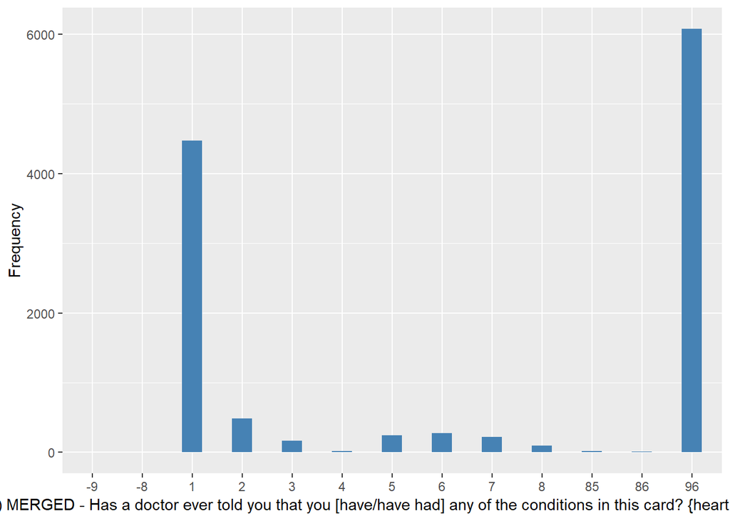

hedim02

| Sample size | Missing values |
| --- | --- |
| 12099 | 9973 |

Category

|  | 2 | 3 | 4 | 5 | 6 | 7 | 8 | 85 | 86 | 96 |
| --- | --- | --- | --- | --- | --- | --- | --- | --- | --- | --- |
| Frequency | 661.00 | 286.00 | 42.00 | 205.00 | 283.00 | 413.00 | 198.00 | 20.00 | 16.00 | 2.00 |
| Percentage | 5.46 | 2.36 | 0.35 | 1.69 | 2.34 | 3.41 | 1.64 | 0.17 | 0.13 | 0.02 |

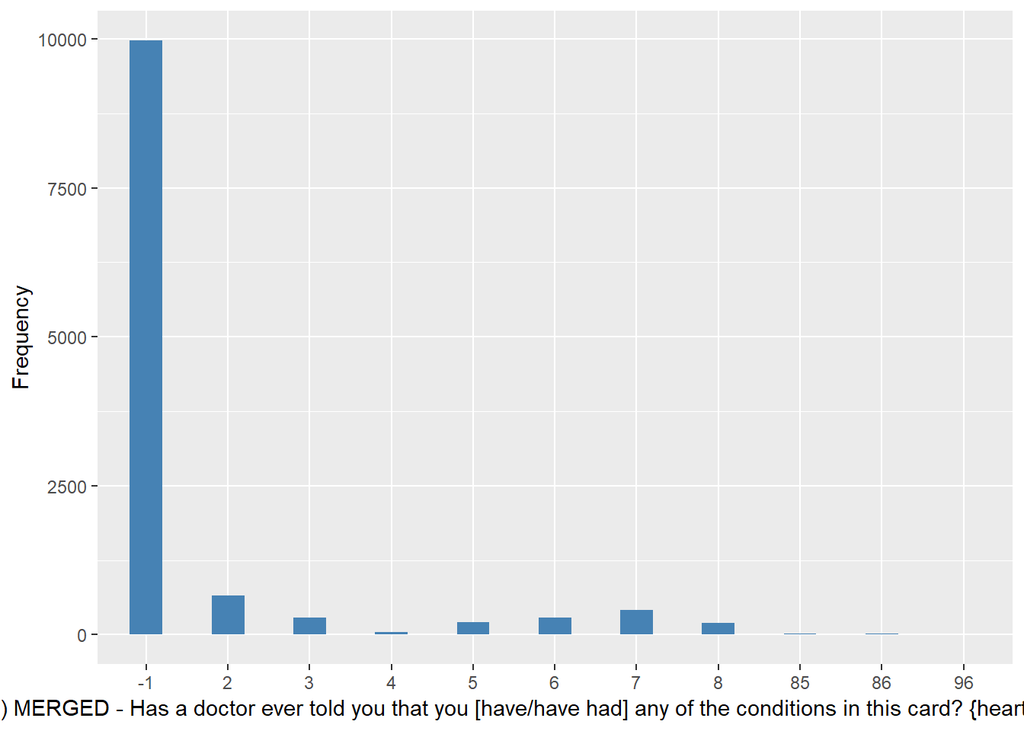

hedim03

| Sample size | Missing values |
| --- | --- |
| 12099 | 11350 |

Category

|  | 3 | 4 | 5 | 6 | 7 | 8 | 85 | 86 | 96 |
| --- | --- | --- | --- | --- | --- | --- | --- | --- | --- |
| Frequency | 248.00 | 26.00 | 69.00 | 117.00 | 151.00 | 112.00 | 19.00 | 6.00 | 1.00 |
| Percentage | 2.05 | 0.21 | 0.57 | 0.97 | 1.25 | 0.93 | 0.16 | 0.05 | 0.01 |

[figure not shown]

hedim04

| Sample size | Missing values |
| --- | --- |
| 12099 | 11837 |

Category

|  | 4 | 5 | 6 | 7 | 8 | 85 |
| --- | --- | --- | --- | --- | --- | --- |
| Frequency | 20.00 | 24.0 | 70.00 | 67.00 | 70.00 | 11.00 |
| Percentage | 0.17 | 0.2 | 0.58 | 0.55 | 0.58 | 0.09 |

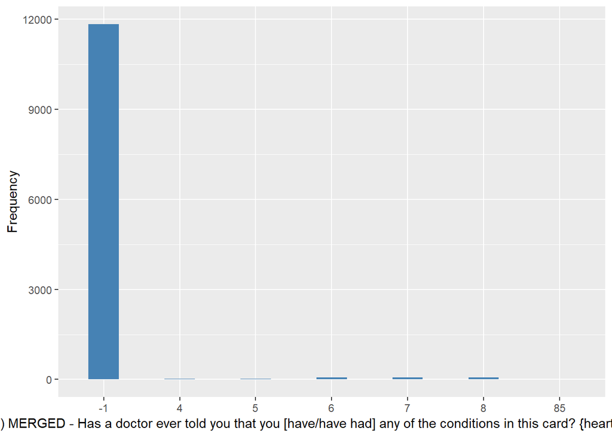

hedim05

| Sample size | Missing values |
| --- | --- |
| 12099 | 12027 |

Category

|  | 5 | 6 | 7 | 8 | 85 | 86 |
| --- | --- | --- | --- | --- | --- | --- |
| Frequency | 9.00 | 12.0 | 16.00 | 32.00 | 2.00 | 1.00 |
| Percentage | 0.07 | 0.1 | 0.13 | 0.26 | 0.02 | 0.01 |

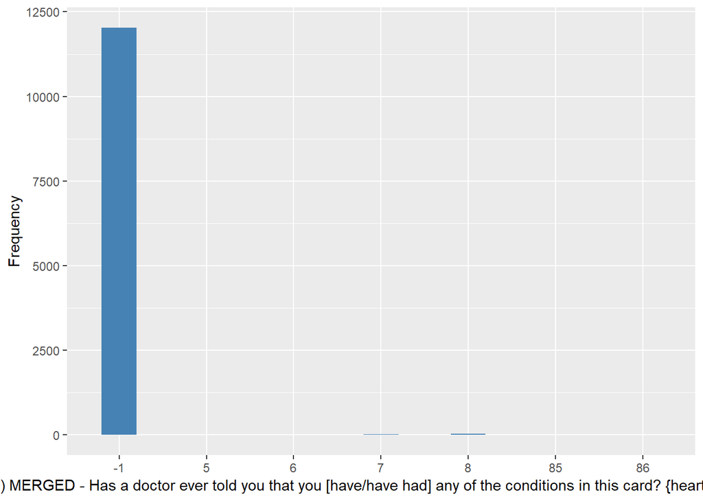

hedim06

| Sample size | Missing values |
| --- | --- |
| 12099 | 12090 |

Category

|  | 6 | 7 | 8 |
| --- | --- | --- | --- |
| Frequency | 5.00 | 1.00 | 3.00 |
| Percentage | 0.04 | 0.01 | 0.02 |

[figure not shown]

hedim07

| Sample size | Missing values |
| --- | --- |
| 12099 | 12096 |

Category

|  | 8 |
| --- | --- |
| Frequency | 3.00 |
| Percentage | 0.02 |

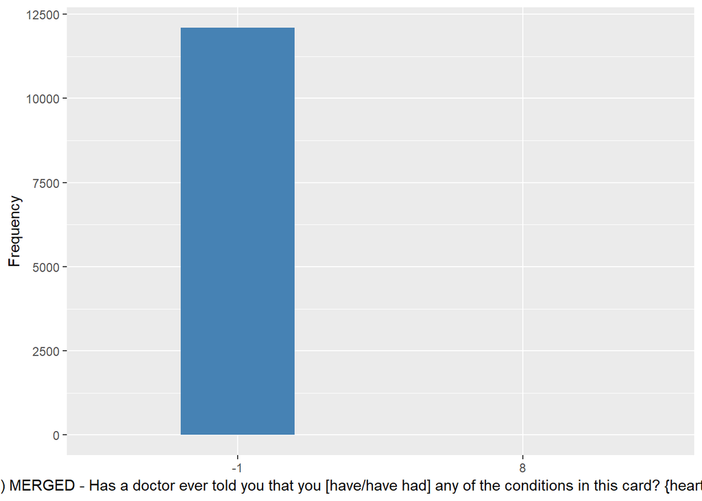

heage

| Sample size | Missing values |
| --- | --- |
| 12099 | 11704 |

Summary

| Min. | 1st Qu. | Median | Mean | 3rd Qu. | Max. |
| --- | --- | --- | --- | --- | --- |
| 16 | 59 | 68 | 66.8 | 76 | 92 |

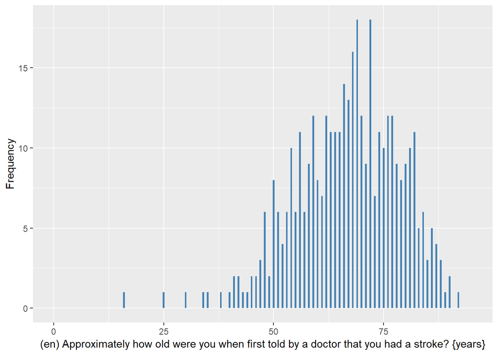

#### 2.1.1.2 Harmonisation algorithm

To compute `stroke` from the study-specific variable it has to be recoded as follows:

- `some hedimX == 8 into 1`
- `-9 into 997`
- `-8 into 998`
- `otherwise into 0`

To compute `stroke_age` from the study-specific variable it has to be recoded as follows:

- `if stroke == 1, stroke_age = heage`
- `if stroke == 0, stroke_age = 996`
- `-9 into 997`
- `-8 into 998`
- `-1 into 996`
- `otherwise, stroke_age = 999`

**R script:**

```r
# Categorical variable harmonization
ELSA_ds_w1 <- tibble(id = ELSA_w1$id)
ELSA_ds_w1$stroke <- rep(0, length(ELSA_w1$id))
ELSA_ds_w1$stroke[which(ELSA_w1$hedim01 == 8 | ELSA_w1$hedim02 == 8 | ELSA_w1$hedim03 ==
    8 | ELSA_w1$hedim04 == 8 | ELSA_w1$hedim05 == 8 | ELSA_w1$hedim06 == 8 |
    ELSA_w1$hedim07 == 8)] <- 1
ELSA_ds_w1$stroke[which(ELSA_w1$hedim01 == -9)] <- 997
ELSA_ds_w1$stroke[which(ELSA_w1$hedim01 == -8)] <- 998

# Continuous variable harmonization
ELSA_ds_w1$stroke_age <- rep(999, length(ELSA_w1$id))
ELSA_ds_w1$stroke_age[which(ELSA_ds_w1$stroke == 0)] <- 996
ELSA_ds_w1$stroke_age[which(ELSA_ds_w1$stroke == 1)] <- car::recode(ELSA_w1$heage[which(ELSA_ds_w1$stroke ==
    1)], "-1=996;-8=998;-9=997")
```

#### 2.1.1.3 Statistics of the new harmonized variable

Stroke

| Sample size | Missing values |
| --- | --- |
| 12099 | 9 |

Category

|  | 0 | 1 |
| --- | --- | --- |
| Frequency | 11574.00 | 516.00 |
| Percentage | 95.66 | 4.26 |

Type of missing

|  | 991 | 992 | 993 | 994 | 995 | 996 | 997 | 998 | 999 | NA |
| --- | --- | --- | --- | --- | --- | --- | --- | --- | --- | --- |
| Frequency | 0 | 0 | 0 | 0 | 0 | 0 | 3.00 | 6.00 | 0 | 0 |
| Percentage | 0 | 0 | 0 | 0 | 0 | 0 | 0.02 | 0.05 | 0 | 0 |

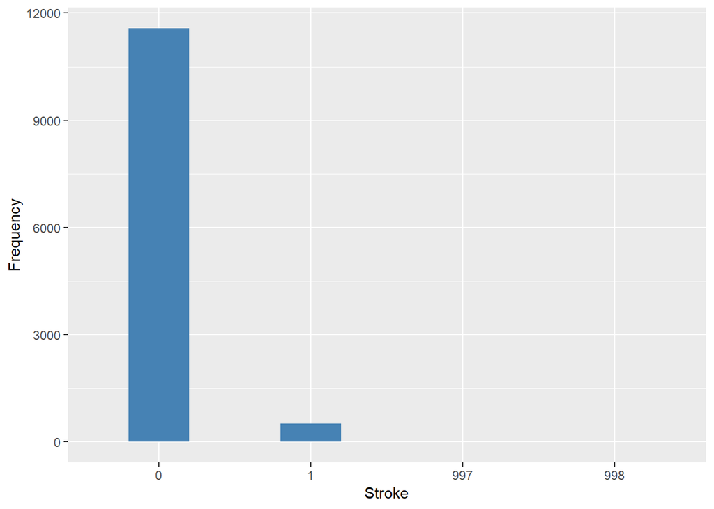

Age of each episode of stroke

| Sample size | Missing values |
| --- | --- |
| 12099 | 11704 |

Values

|  | No-missings | 991 | 992 | 993 | 994 | 995 | 996 | 997 | 998 | 999 | NA |
| --- | --- | --- | --- | --- | --- | --- | --- | --- | --- | --- | --- |
| Frequency | 395.00 | 0 | 0 | 0 | 0 | 0 | 11693.00 | 0 | 2.00 | 9.00 | 0 |
| Percentage | 3.26 | 0 | 0 | 0 | 0 | 0 | 96.64 | 0 | 0.02 | 0.07 | 0 |

Summary

| Min. | 1st Qu. | Median | Mean | 3rd Qu. | Max. |
| --- | --- | --- | --- | --- | --- |
| 16 | 59 | 68 | 66.8 | 76 | 92 |

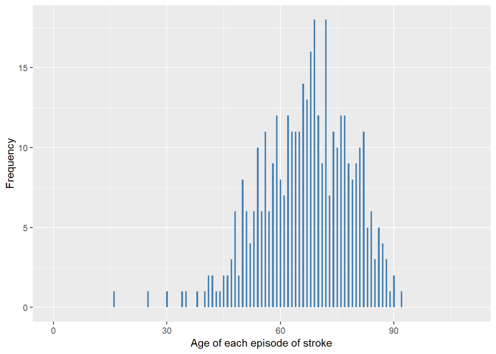

#### 2.1.1.4 Validation

|  | hedimX!=8->0 | hedimX==8->1 | hedimX==-9->997 | hedimX==-8->998 |
| --- | --- | --- | --- | --- |
| BeforeH | 11574 | 516 | 3 | 6 |
| AfterH | 11574 | 516 | 3 | 6 |

### 2.1.2 Wave 2

#### 2.1.2.1 Study-specific variable description

| **Name** | `hedim01` | `hedim02` | `hedim03` | `hedim04` | `hedim05` | `hedim06` | `hedim07` | `hedim08` | `hedia01` | `HeAgeRY` | `ybirth` |
| --- | --- | --- | --- | --- | --- | --- | --- | --- | --- | --- | --- |
| **Label** | `Diagnosed cardiovascular condit. newly reported at W2 (1st mention) (merged var)` | `Diagnosed cardiovascular condit. newly reported at W2 (2nd mention) (merged var)` | `Diagnosed cardiovascular condit. newly reported at W2 (3rd mention) (merged var)` | `Diagnosed cardiovascular condit. newly reported at W2 (4th mention) (merged var)` | `Diagnosed cardiovascular condit. newly reported at W2 (5th mention) (merged var)` | `Diagnosed cardiovascular condit. newly reported at W2 (6th mention) (merged var)` | `Diagnosed cardiovascular condit. newly reported at W2 (7th mention) (merged var)` | `Diagnosed cardiovascular condit. newly reported at W2 (8th mention) (merged var)` | `Diagnosed cardiovascular condition newly reported at W2 (1st mention)` | `Year told had stroke in last 2 years` | `year of birth` |
| **Table name** | `wave_2_core_data_v4` | `wave_2_core_data_v4` | `wave_2_core_data_v4` | `wave_2_core_data_v4` | `wave_2_core_data_v4` | `wave_2_core_data_v4` | `wave_2_core_data_v4` | `wave_2_core_data_v4` | `wave_2_core_data_v4` | `wave_2_core_data_v4` | `elsa_w2_hd` |
| **Categories** | `1 = High blood pressure or hypertension` `2 = Angina` `3 = A heart attack (including myocardial infarction or coronary)` `4 = Congestive heart failure` `5 = A heart murmur` `6 = An abnormal heart rhy… | `1 = High blood pressure or hypertension` `2 = Angina` `3 = A heart attack (including myocardial infarction or coronary)` `4 = Congestive heart failure` `5 = A heart murmur` `6 = An abnormal heart rhy… | `1 = High blood pressure or hypertension` `2 = Angina` `3 = A heart attack (including myocardial infarction or coronary)` `4 = Congestive heart failure` `5 = A heart murmur` `6 = An abnormal heart rhy… | `1 = High blood pressure or hypertension` `2 = Angina` `3 = A heart attack (including myocardial infarction or coronary)` `4 = Congestive heart failure` `5 = A heart murmur` `6 = An abnormal heart rhy… | `1 = High blood pressure or hypertension` `2 = Angina` `3 = A heart attack (including myocardial infarction or coronary)` `4 = Congestive heart failure` `5 = A heart murmur` `6 = An abnormal heart rhy… | `1 = High blood pressure or hypertension` `2 = Angina` `3 = A heart attack (including myocardial infarction or coronary)` `4 = Congestive heart failure` `5 = A heart murmur` `6 = An abnormal heart rhy… | `1 = High blood pressure or hypertension` `2 = Angina` `3 = A heart attack (including myocardial infarction or coronary)` `4 = Congestive heart failure` `5 = A heart murmur` `6 = An abnormal heart rhy… | `1 = High blood pressure or hypertension` `2 = Angina` `3 = A heart attack (including myocardial infarction or coronary)` `4 = Congestive heart failure` `5 = A heart murmur` `6 = An abnormal heart rhy… | `1 = High blood pressure or hypertension` `2 = Angina` `3 = A heart attack (including myocardial infarction or coronary)` `4 = Congestive heart failure` `5 = A heart murmur` `6 = An abnormal heart rhy… | `continuous` | `continuous` |
| **Missings** | `-9 = Refusal` `-8 = Don't know` `-1 = Not applicable` | `-9 = Refusal` `-8 = Don't know` `-1 = Not applicable` | `-9 = Refusal` `-8 = Don't know` `-1 = Not applicable` | `-9 = Refusal` `-8 = Don't know` `-1 = Not applicable` | `-9 = Refusal` `-8 = Don't know` `-1 = Not applicable` | `-9 = Refusal` `-8 = Don't know` `-1 = Not applicable` | `-9 = Refusal` `-8 = Don't know` `-1 = Not applicable` | `-9 = Refusal` `-8 = Don't know` `-1 = Not applicable` | `-9 = Refusal` `-8 = Don't know` `-1 = Not applicable` | `-9 = Refusal` `-8 = Don't know` `-1 = Not applicable` |  |
| **Description** |  |  |  |  |  |  |  |  |  |  |  |

hedim01

| Sample size | Missing values |
| --- | --- |
| 9432 | 9 |

Category

|  | 1 | 2 | 3 | 4 | 5 | 6 | 7 | 8 | 9 | 51 | 52 | 85 | 86 | 96 |
| --- | --- | --- | --- | --- | --- | --- | --- | --- | --- | --- | --- | --- | --- | --- |
| Frequency | 1707.0 | 213.00 | 59.00 | 14.00 | 91.00 | 196.00 | 171.00 | 76.00 | 946.00 | 6.00 | 7.00 | 27.00 | 8.00 | 5902.00 |
| Percentage | 18.1 | 2.26 | 0.63 | 0.15 | 0.96 | 2.08 | 1.81 | 0.81 | 10.03 | 0.06 | 0.07 | 0.29 | 0.08 | 62.57 |

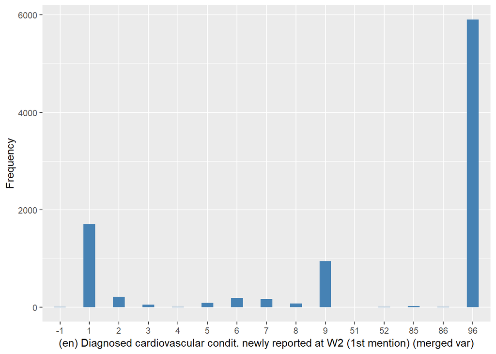

hedim02

| Sample size | Missing values |
| --- | --- |
| 9432 | 8262 |

Category

|  | 2 | 3 | 4 | 5 | 6 | 7 | 8 | 9 | 51 | 52 | 85 | 86 |
| --- | --- | --- | --- | --- | --- | --- | --- | --- | --- | --- | --- | --- |
| Frequency | 148.00 | 51.00 | 7.00 | 59.00 | 110.00 | 151.0 | 63.00 | 546.00 | 8.00 | 4.00 | 18.00 | 5.00 |
| Percentage | 1.57 | 0.54 | 0.07 | 0.63 | 1.17 | 1.6 | 0.67 | 5.79 | 0.08 | 0.04 | 0.19 | 0.05 |

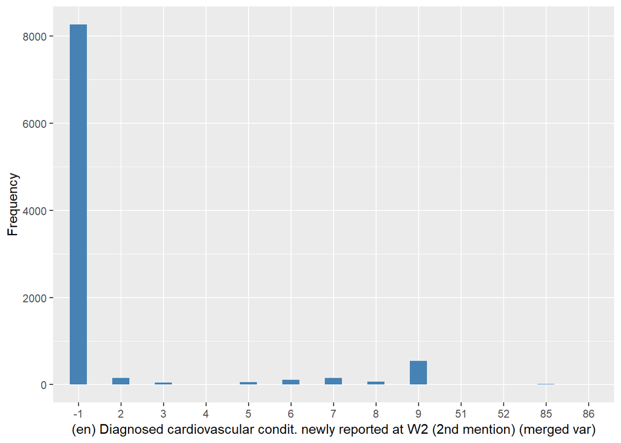

hedim03

| Sample size | Missing values |
| --- | --- |
| 9432 | 9078 |

Category

|  | 3 | 4 | 5 | 6 | 7 | 8 | 9 | 51 | 52 | 85 |
| --- | --- | --- | --- | --- | --- | --- | --- | --- | --- | --- |
| Frequency | 22.00 | 3.00 | 17.00 | 31.00 | 54.00 | 24.00 | 175.00 | 8.00 | 7.00 | 13.00 |
| Percentage | 0.23 | 0.03 | 0.18 | 0.33 | 0.57 | 0.25 | 1.86 | 0.08 | 0.07 | 0.14 |

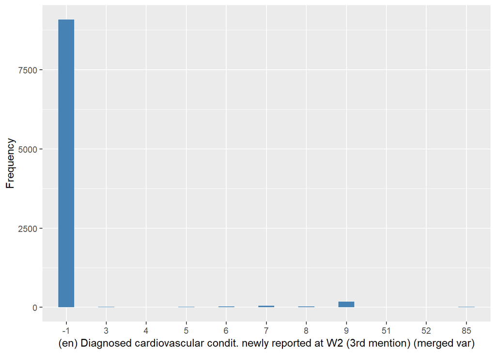

hedim04

| Sample size | Missing values |
| --- | --- |
| 9432 | 9336 |

Category

|  | 4 | 5 | 6 | 7 | 8 | 9 | 51 | 52 | 85 |
| --- | --- | --- | --- | --- | --- | --- | --- | --- | --- |
| Frequency | 2.00 | 3.00 | 3.00 | 8.00 | 6.00 | 60.00 | 7.00 | 4.00 | 3.00 |
| Percentage | 0.02 | 0.03 | 0.03 | 0.08 | 0.06 | 0.64 | 0.07 | 0.04 | 0.03 |

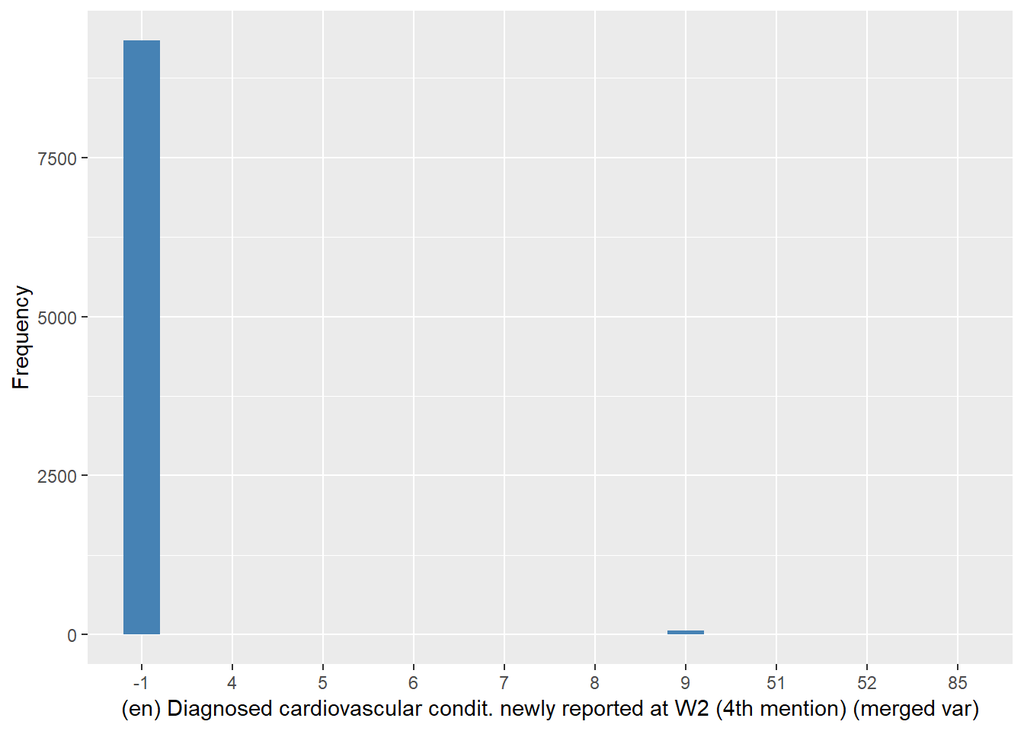

hedim05

| Sample size | Missing values |
| --- | --- |
| 9432 | 9414 |

Category

|  | 6 | 8 | 9 | 51 | 52 | 85 |
| --- | --- | --- | --- | --- | --- | --- |
| Frequency | 3.00 | 1.00 | 10.00 | 2.00 | 1.00 | 1.00 |
| Percentage | 0.03 | 0.01 | 0.11 | 0.02 | 0.01 | 0.01 |

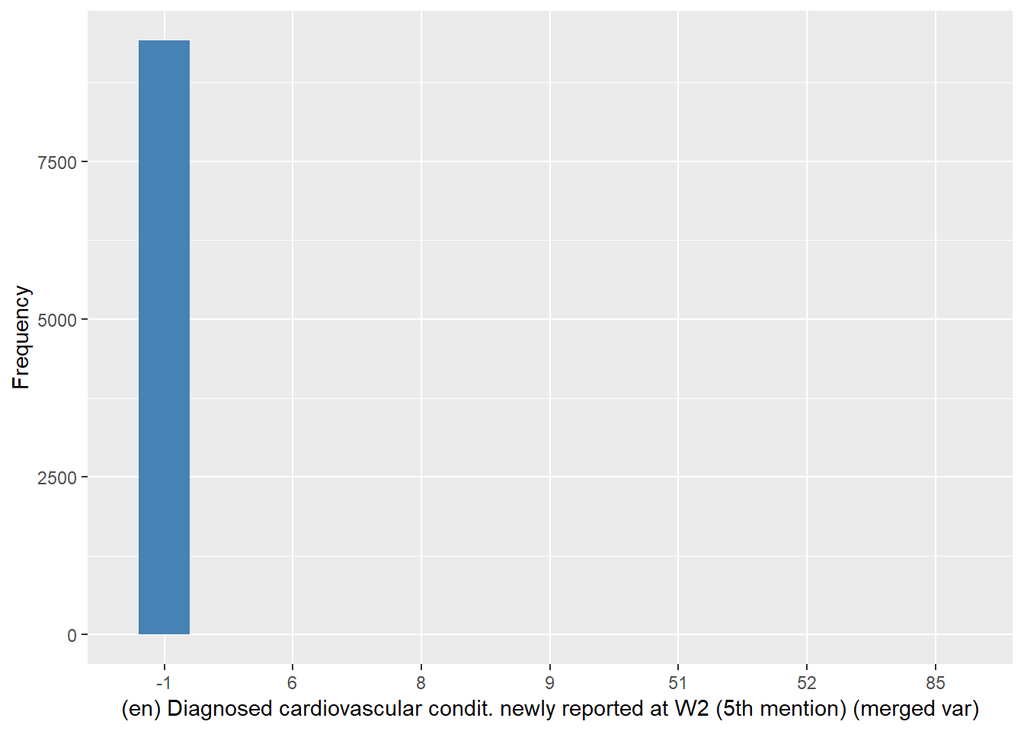

hedim06

| Sample size | Missing values |
| --- | --- |
| 9432 | 9427 |

Category

|  | 7 | 9 | 52 |
| --- | --- | --- | --- |
| Frequency | 1.00 | 3.00 | 1.00 |
| Percentage | 0.01 | 0.03 | 0.01 |

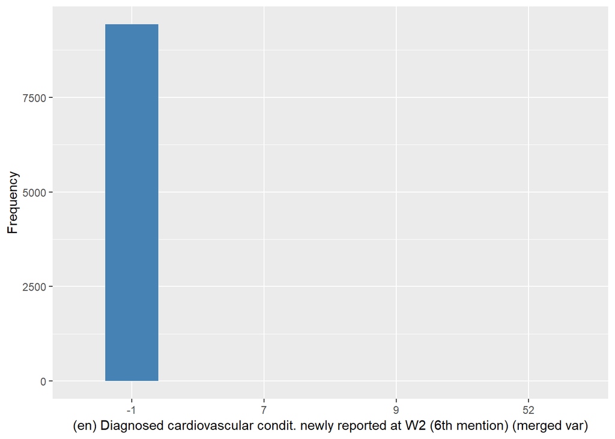

hedim07

| Sample size | Missing values |
| --- | --- |
| 9432 | 9431 |

Category

|  | 9 |
| --- | --- |
| Frequency | 1.00 |
| Percentage | 0.01 |

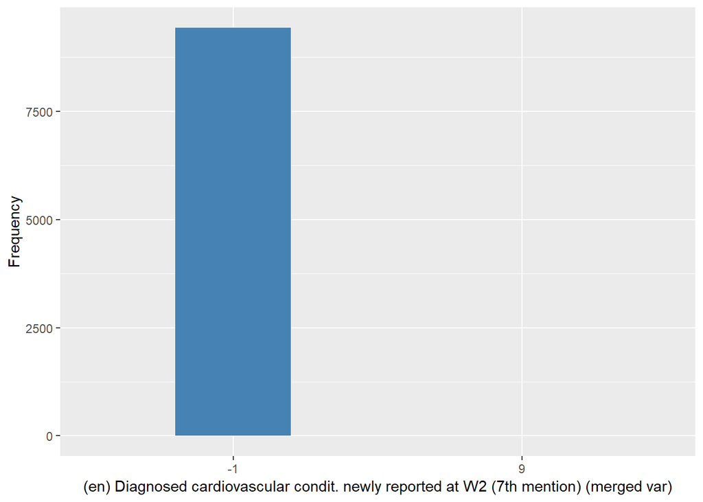

hedim08

| Sample size | Missing values |
| --- | --- |
| 9432 | 9431 |

Category

|  | 52 |
| --- | --- |
| Frequency | 1.00 |
| Percentage | 0.01 |

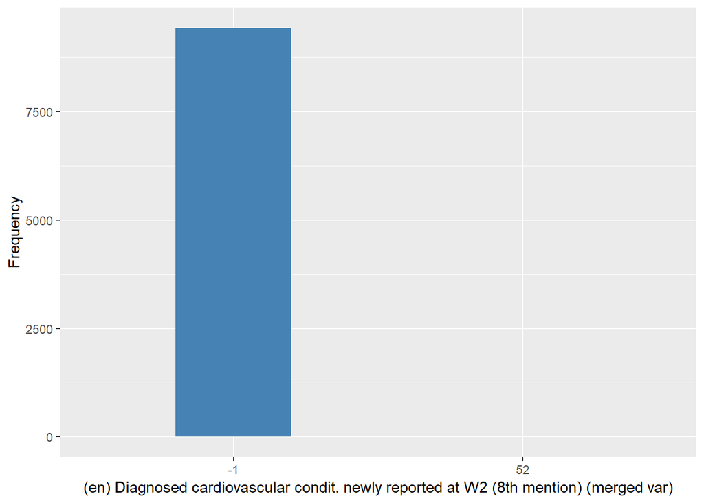

hedia01

| Sample size | Missing values |
| --- | --- |
| 9432 | 9 |

Category

|  | 1 | 2 | 3 | 4 | 5 | 6 | 7 | 8 | 9 | 95 | 96 |
| --- | --- | --- | --- | --- | --- | --- | --- | --- | --- | --- | --- |
| Frequency | 1634.00 | 204.00 | 64.00 | 11.00 | 81.00 | 175.00 | 178.00 | 86.00 | 997.00 | 91.00 | 5902.00 |
| Percentage | 17.32 | 2.16 | 0.68 | 0.12 | 0.86 | 1.86 | 1.89 | 0.91 | 10.57 | 0.96 | 62.57 |

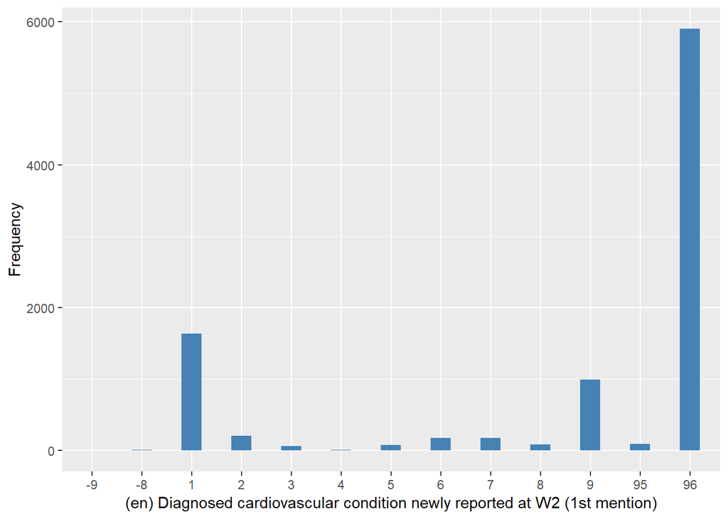

HeAgeRY

| Sample size | Missing values |
| --- | --- |
| 9432 | 0 |

Summary

| Min. | 1st Qu. | Median | Mean | 3rd Qu. | Max. |
| --- | --- | --- | --- | --- | --- |
| -8 | -1 | -1 | 32.57 | -1 | 2005 |

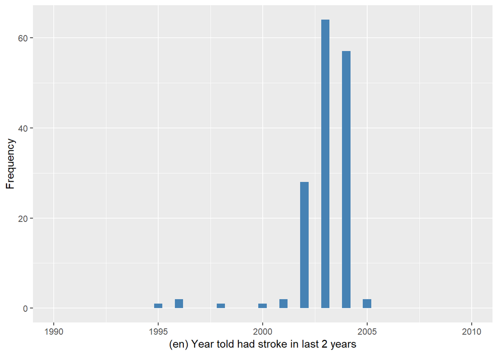

ybirth

| Sample size | Missing values |
| --- | --- |
| 9432 | 0 |

Summary

| Min. | 1st Qu. | Median | Mean | 3rd Qu. | Max. |
| --- | --- | --- | --- | --- | --- |
| 1908 | 1931 | 1939 | 1938 | 1947 | 1987 |

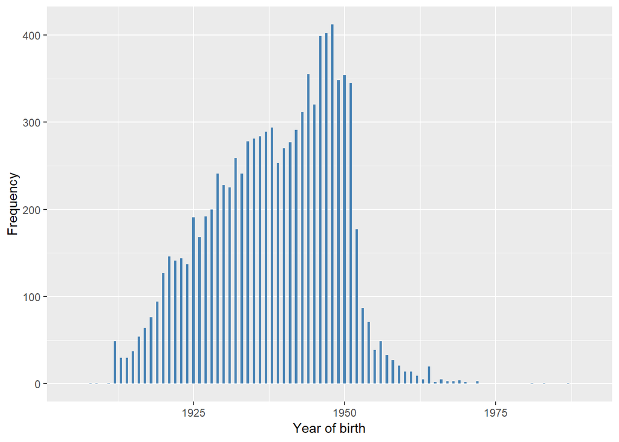

#### 2.1.2.2 Harmonisation algorithm

To compute `stroke` from the study-specific variable it has to be recoded as follows:

- `some hedimX == 8 into 1`
- `hedia01 == -9 and hedimX == -1 into 997`
- `hedia01 == -8 and hedimX == -1 into 998`
- `otherwise into 0`

To compute `stroke_age` from the study-specific variable it has to be recoded as follows:

- `if stroke == 1, stroke_age = HeAgeRY - ybirth`
- `if stroke == 0, stroke_age = 996`
- `-9 into 997`
- `-8 into 998`
- `-1 into 996`
- `otherwise, stroke_age = 999`

**R script:**

```r
# Categorical variable harmonization
ELSA_ds_w2 <- tibble(id = ELSA_w2$id)
ELSA_ds_w2$stroke <- rep(0, length(ELSA_w2$id))
ELSA_ds_w2$stroke[which(ELSA_w2$hedim01 == 8 | ELSA_w2$hedim02 == 8 | ELSA_w2$hedim03 ==
    8 | ELSA_w2$hedim04 == 8 | ELSA_w2$hedim05 == 8 | ELSA_w2$hedim06 == 8 |
    ELSA_w2$hedim07 == 8 | ELSA_w2$hedim08 == 8)] <- 1
ELSA_ds_w2$stroke[which(ELSA_w2$hedia01 == -9 & ELSA_w2$hedim01 == -1)] <- 997
ELSA_ds_w2$stroke[which(ELSA_w2$hedia01 == -8 & ELSA_w2$hedim01 == -1)] <- 998

# Continuous variable harmonization
ELSA_ds_w2$stroke_age <- rep(999, length(ELSA_w2$id))
ELSA_ds_w2$stroke_age[which(ELSA_ds_w2$stroke == 0)] <- 996
ELSA_ds_w2$stroke_age[which(ELSA_ds_w2$stroke == 1 & !ELSA_w2$HeAgeRY %in% c(-1,
    -8, -9))] <- ELSA_w2$HeAgeRY[which(ELSA_ds_w2$stroke == 1 & !ELSA_w2$HeAgeRY %in%
    c(-1, -8, -9))] - ELSA_w2$ybirth[which(ELSA_ds_w2$stroke == 1 & !ELSA_w2$HeAgeRY %in%
    c(-1, -8, -9))]
ELSA_ds_w2$stroke_age <- car::recode(ELSA_ds_w2$stroke_age, "-1=996;-8=998;-9=997;NA=999")
```

#### 2.1.2.3 Statistics of the new harmonized variable

Stroke

| Sample size | Missing values |
| --- | --- |
| 9432 | 9 |

Category

|  | 0 | 1 |
| --- | --- | --- |
| Frequency | 9253.0 | 170.0 |
| Percentage | 98.1 | 1.8 |

Type of missing

|  | 991 | 992 | 993 | 994 | 995 | 996 | 997 | 998 | 999 | NA |
| --- | --- | --- | --- | --- | --- | --- | --- | --- | --- | --- |
| Frequency | 0 | 0 | 0 | 0 | 0 | 0 | 1.00 | 8.00 | 0 | 0 |
| Percentage | 0 | 0 | 0 | 0 | 0 | 0 | 0.01 | 0.08 | 0 | 0 |

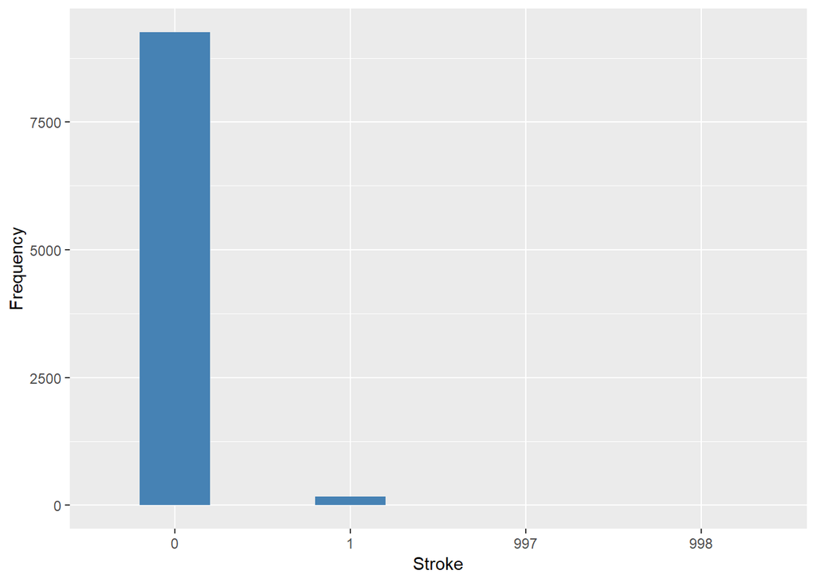

Age of each episode of stroke

| Sample size | Missing values |
| --- | --- |
| 9432 | 9274 |

Values

|  | No-missings | 991 | 992 | 993 | 994 | 995 | 996 | 997 | 998 | 999 | NA |
| --- | --- | --- | --- | --- | --- | --- | --- | --- | --- | --- | --- |
| Frequency | 158.00 | 0 | 0 | 0 | 0 | 0 | 9253.0 | 0 | 0 | 21.00 | 0 |
| Percentage | 1.68 | 0 | 0 | 0 | 0 | 0 | 98.1 | 0 | 0 | 0.22 | 0 |

Summary

| Min. | 1st Qu. | Median | Mean | 3rd Qu. | Max. |
| --- | --- | --- | --- | --- | --- |
| 53 | 67 | 74 | 73.84 | 81 | 91 |

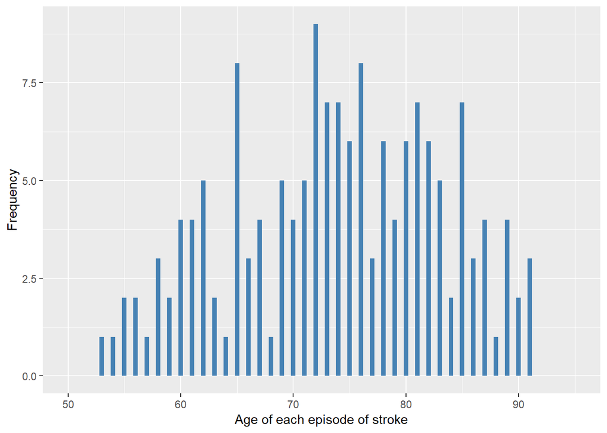

#### 2.1.2.4 Validation

|  | hedimX!=8->0 | hedimX==8->1 | hedimX==-9->997 | hedimX==-8->998 |
| --- | --- | --- | --- | --- |
| BeforeH | 9253 | 170 | 1 | 8 |
| AfterH | 9253 | 170 | 1 | 8 |

### 2.1.3 Wave 3

#### 2.1.3.1 Study-specific variable description

| **Name** | `dhedimst` | `ybirth` | `heagery` |
| --- | --- | --- | --- |
| **Label** | `CVD: stroke diagnosis newly reported (merged)` | `year of birth` | `Year told had stroke since last interview` |
| **Table name** | `wave_3_elsa_data_v4` | `elsa_w3_hd` | `wave_3_elsa_data_v4` |
| **Categories** | `1 = Mentioned` `0 = Not mentioned` | `continuous` | `continuous` |
| **Missings** | `-9 = Refusal` `-8 = Don't know` `-1 = Not applicable` | `998 = Do not know` | `-9 = Refusal` `-8 = Don't know` `-1 = Not applicable` |
| **Description** |  |  |  |

dhedimst

| Sample size | Missing values |
| --- | --- |
| 9771 | 5 |

Category

|  | 0 | 1 |
| --- | --- | --- |
| Frequency | 9655.00 | 111.00 |
| Percentage | 98.81 | 1.14 |

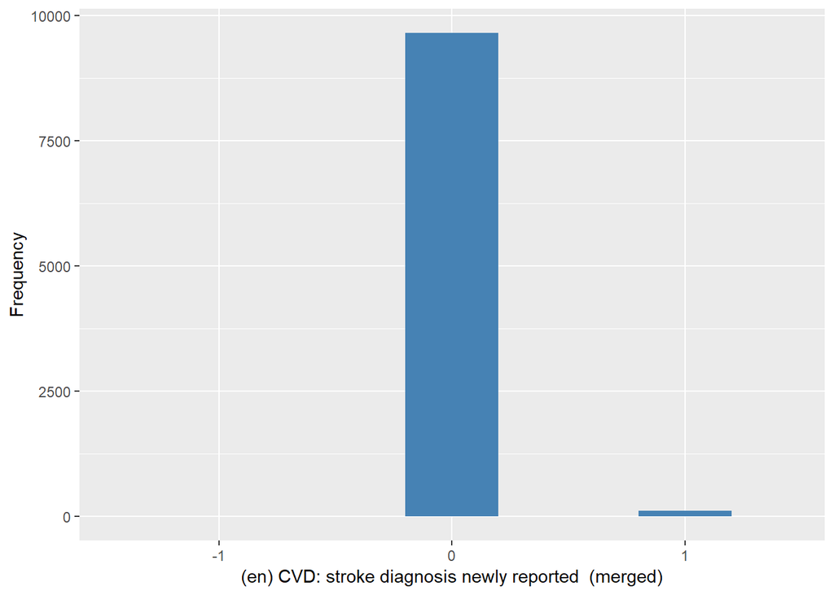

ybirth

| Sample size | Missing values |
| --- | --- |
| 9771 | 1 |

Summary

| Min. | 1st Qu. | Median | Mean | 3rd Qu. | Max. |
| --- | --- | --- | --- | --- | --- |
| 1908 | 1933 | 1943 | 1941 | 1950 | 1987 |

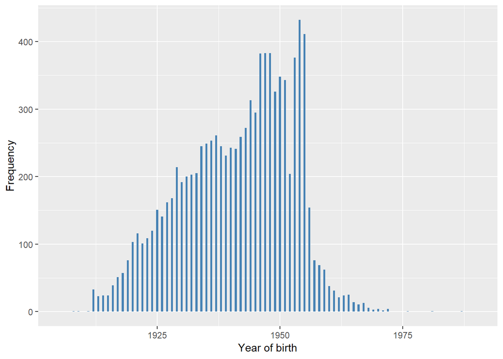

heagery

| Sample size | Missing values |
| --- | --- |
| 9771 | 9683 |

Summary

| Min. | 1st Qu. | Median | Mean | 3rd Qu. | Max. |
| --- | --- | --- | --- | --- | --- |
| 1993 | 2004 | 2005 | 2004 | 2005 | 2006 |

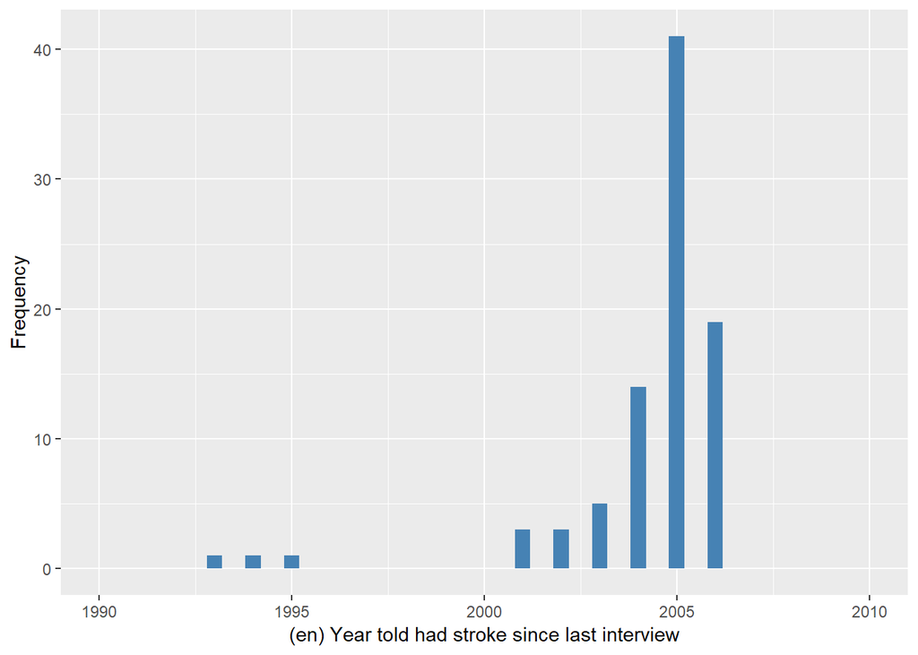

#### 2.1.3.2 Harmonisation algorithm

To compute `stroke` from the study-specific variable it has to be recoded as follows:

- `dhedimst == 1 into 1`
- `dhedimst == 0 into 0`
- `dhedimst == -1 into 996`

To compute `stroke_age` from the study-specific variable it has to be recoded as follows:

- `if stroke == 1, stroke_age = heagery - ybirth`
- `if stroke == 0, stroke_age = 996`
- `-9 into 997`
- `-8 into 998`
- `-1 into 996`
- `otherwise, stroke_age = 999`

**R script:**

```r
# Categorical variable harmonization
ELSA_ds_w3 <- tibble(id = ELSA_w3$id)
ELSA_ds_w3$stroke <- car::recode(ELSA_w3$dhedimst, "-1=996")

# Continuous variable harmonization
ELSA_ds_w3$stroke_age <- rep(999, length(ELSA_w3$id))
ELSA_ds_w3$stroke_age[which(ELSA_ds_w3$stroke == 0)] <- 996
ELSA_ds_w3$stroke_age[which(ELSA_ds_w3$stroke == 1 & !ELSA_w3$heagery %in% c(-1,
    -8, -9) & ELSA_w3$ybirth != 998)] <- ELSA_w3$heagery[which(ELSA_ds_w3$stroke ==
    1 & !ELSA_w3$heagery %in% c(-1, -8, -9) & ELSA_w3$ybirth != 998)] - ELSA_w3$ybirth[which(ELSA_ds_w3$stroke ==
    1 & !ELSA_w3$heagery %in% c(-1, -8, -9) & ELSA_w3$ybirth != 998)]
ELSA_ds_w3$stroke_age <- car::recode(ELSA_ds_w3$stroke_age, "-1=996;-8=998;-9=997;NA=999")
```

#### 2.1.3.3 Statistics of the new harmonized variable

Stroke

| Sample size | Missing values |
| --- | --- |
| 9771 | 5 |

Category

|  | 0 | 1 |
| --- | --- | --- |
| Frequency | 9655.00 | 111.00 |
| Percentage | 98.81 | 1.14 |

Type of missing

|  | 991 | 992 | 993 | 994 | 995 | 996 | 997 | 998 | 999 | NA |
| --- | --- | --- | --- | --- | --- | --- | --- | --- | --- | --- |
| Frequency | 0 | 0 | 0 | 0 | 0 | 5.00 | 0 | 0 | 0 | 0 |
| Percentage | 0 | 0 | 0 | 0 | 0 | 0.05 | 0 | 0 | 0 | 0 |

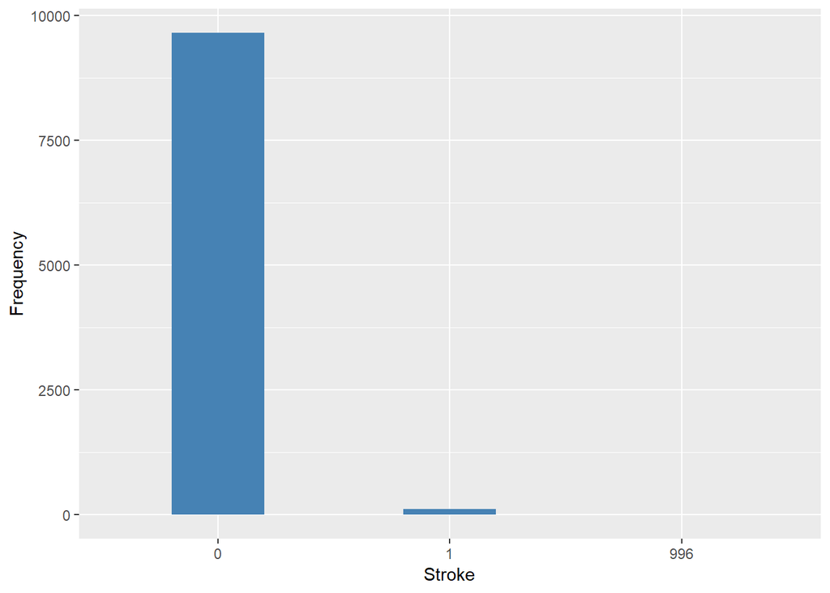

Age of each episode of stroke

| Sample size | Missing values |
| --- | --- |
| 9771 | 9683 |

Values

|  | No-missings | 991 | 992 | 993 | 994 | 995 | 996 | 997 | 998 | 999 | NA |
| --- | --- | --- | --- | --- | --- | --- | --- | --- | --- | --- | --- |
| Frequency | 88.0 | 0 | 0 | 0 | 0 | 0 | 9655.00 | 0 | 0 | 28.00 | 0 |
| Percentage | 0.9 | 0 | 0 | 0 | 0 | 0 | 98.81 | 0 | 0 | 0.29 | 0 |

Summary

| Min. | 1st Qu. | Median | Mean | 3rd Qu. | Max. |
| --- | --- | --- | --- | --- | --- |
| 53 | 66 | 73.5 | 73.66 | 81.25 | 93 |

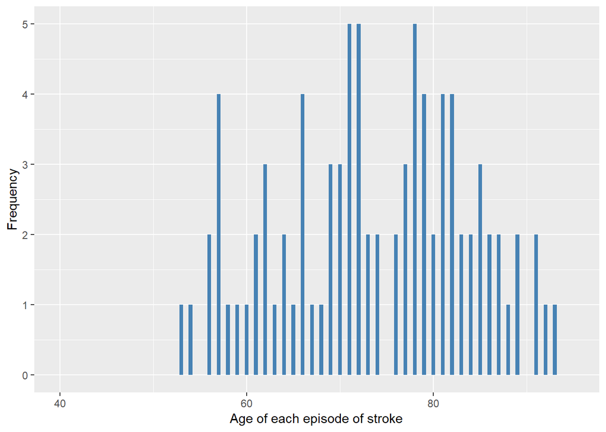

#### 2.1.3.4 Validation

|  | dhedimst==0->0 | dhedimst==1->1 | dhedimst==-1->996 |
| --- | --- | --- | --- |
| BeforeH | 9655 | 111 | 5 |
| AfterH | 9655 | 111 | 5 |

### 2.1.4 Wave 4

#### 2.1.4.1 Study-specific variable description

| **Name** | `hedimst` | `ybirth` | `heagery` |
| --- | --- | --- | --- |
| **Label** | `CVD: stroke diagnosis newly reported (merged)` | `year of birth` | `Year told had stroke since last interview` |
| **Table name** | `wave_4_elsa_data_v3` | `elsa_w4_hd` | `wave_4_elsa_data_v3` |
| **Categories** | `1 = Mentioned` `0 = Not mentioned` | `continuous` | `continuous` |
| **Missings** | `-9 = Refusal` `-8 = Don't know` `-1 = Not applicable` |  | `-9 = Refusal` `-8 = Don't know` `-2 = Capi/Interview Error` `-1 = Not applicable` |
| **Description** |  |  |  |

hedimst

| Sample size | Missing values |
| --- | --- |
| 11050 | 16 |

Category

|  | 0 | 1 |
| --- | --- | --- |
| Frequency | 10851.0 | 183.00 |
| Percentage | 98.2 | 1.66 |

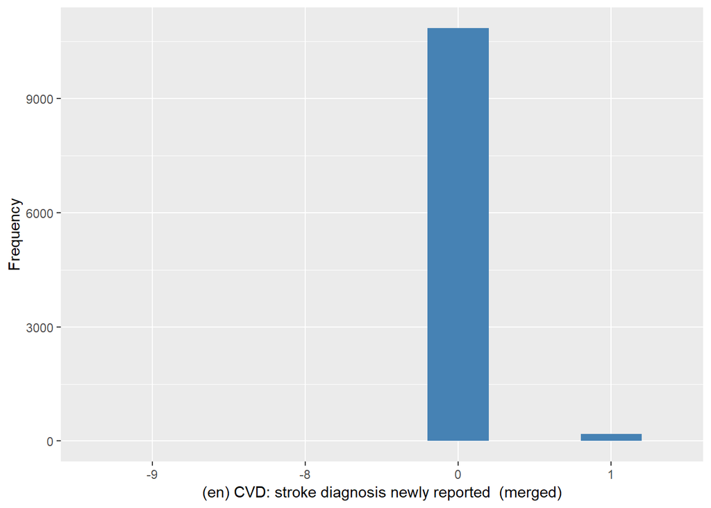

heagery

| Sample size | Missing values |
| --- | --- |
| 11050 | 10955 |

Summary

| Min. | 1st Qu. | Median | Mean | 3rd Qu. | Max. |
| --- | --- | --- | --- | --- | --- |
| 1995 | 2007 | 2007 | 2007 | 2008 | 2009 |

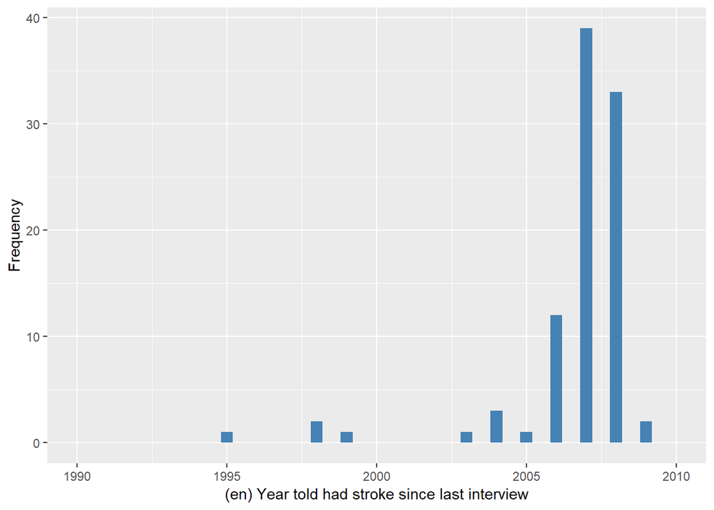

ybirth

| Sample size | Missing values |
| --- | --- |
| 11050 | 0 |

Summary

| Min. | 1st Qu. | Median | Mean | 3rd Qu. | Max. |
| --- | --- | --- | --- | --- | --- |
| 1908 | 1936 | 1944 | 1943 | 1951 | 1984 |

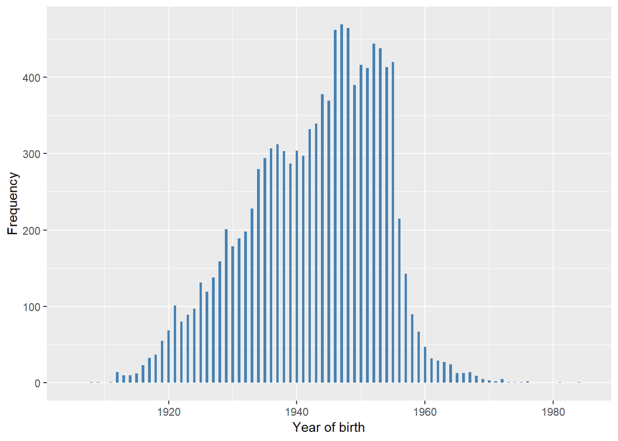